# Lab 2

Shannon Lynch

2/3/2022

## Question 1

**For the gapminder data, order countries in reverse alphabetical order, then display the first 15. This should work out pretty well in this case, but can you think of any potential issues with this process that might lead to ordering problems in a different dataset? (Hint: Go back to the basics and check to make sure you understand what kind of data you are working with.)**

The package dplyr exists within the tidyverse which overwrites some base R functions when loaded. If your code includes these, you may run into trouble. They also change dataframes into tibbles and thus won’t work with certain data types.

```r
#load libraries

library(gapminder)
library(dplyr)
#examine headers
head(gapminder)
```

```
## # A tibble: 6 x 6
##   country     continent  year lifeExp      pop gdpPercap
##   <fct>       <fct>     <int>   <dbl>    <int>     <dbl>
## 1 Afghanistan Asia       1952    28.8  8425333      779.
## 2 Afghanistan Asia       1957    30.3  9240934      821.
## 3 Afghanistan Asia       1962    32.0 10267083      853.
## 4 Afghanistan Asia       1967    34.0 11537966      836.
## 5 Afghanistan Asia       1972    36.1 13079460      740.
## 6 Afghanistan Asia       1977    38.4 14880372      786.
```

```r
# arrange my data using the arrange function and making it so its decsending by country
gapminder %>%
  arrange(desc(., country)) %>%
  head(15)
```

```
## # A tibble: 15 x 6
##    country  continent  year lifeExp      pop gdpPercap
##    <fct>    <fct>     <int>   <dbl>    <int>     <dbl>
##  1 Zimbabwe Africa     2007    43.5 12311143      470.
##  2 Zimbabwe Africa     2002    40.0 11926563      672.
##  3 Zimbabwe Africa     1997    46.8 11404948      792.
##  4 Zimbabwe Africa     1992    60.4 10704340      693.
##  5 Zimbabwe Africa     1987    62.4  9216418      706.
##  6 Zimbabwe Africa     1982    60.4  7636524      789.
##  7 Zimbabwe Africa     1977    57.7  6642107      686.
##  8 Zimbabwe Africa     1972    55.6  5861135      799.
##  9 Zimbabwe Africa     1967    54.0  4995432      570.
## 10 Zimbabwe Africa     1962    52.4  4277736      527.
## 11 Zimbabwe Africa     1957    50.5  3646340      519.
## 12 Zimbabwe Africa     1952    48.5  3080907      407.
## 13 Zambia   Africa     2007    42.4 11746035     1271.
## 14 Zambia   Africa     2002    39.2 10595811     1072.
## 15 Zambia   Africa     1997    40.2  9417789     1071.
```

## Question 2

**Calculate and display the mean, median, and standard deviation for the Life expectancy, Population, and GDPperCapita in the gapminder dataset.**

```r
#calculating mean, median, and SD for Life expectancy
gapminder %>%
  summarize(LE_mean = mean(lifeExp),
            LE_median = median(lifeExp),
            LE_sd = sd(lifeExp))
```

```
## # A tibble: 1 x 3
##   LE_mean LE_median LE_sd
##     <dbl>     <dbl> <dbl>
## 1    59.5      60.7  12.9
```

```r
#calculating mean, median, and SD for population
gapminder %>%
  summarize(POP_mean = mean(pop),
            POP_median = median(pop),
           POP_sd = sd(pop))
```

```
## # A tibble: 1 x 3
##    POP_mean POP_median     POP_sd
##       <dbl>      <dbl>      <dbl>
## 1 29601212.   7023596. 106157897.
```

```r
#calculating mean, median, and SD for GDPperCapita
gapminder %>%
  summarize(GDP_mean = mean(gdpPercap),
            GDP_median = median(gdpPercap),
           GDP_sd = sd(gdpPercap))
```

```
## # A tibble: 1 x 3
##   GDP_mean GDP_median GDP_sd
##      <dbl>      <dbl>  <dbl>
## 1    7215.      3532.  9857.
```

## Question 3

**Calculate and display in a single dataframe the mean values for Life expectancy, Population, and GDPperCapita for each continent.**

```r
#single dataframe the mean values for Life expectancy, Population, and GDPperCapita grouped by continent
gapminder %>%
  group_by(continent) %>%
  summarize(LE_mean = mean(lifeExp),
            POP_mean = mean(pop),
            GDP_mean = mean(gdpPercap))
```

```
## # A tibble: 5 x 4
##   continent LE_mean  POP_mean GDP_mean
##   <fct>       <dbl>     <dbl>    <dbl>
## 1 Africa       48.9  9916003.    2194.
## 2 Americas     64.7 24504795.    7136.
## 3 Asia         60.1 77038722.    7902.
## 4 Europe       71.9 17169765.   14469.
## 5 Oceania      74.3  8874672.   18622.
```

## Question 4

**Create a scatter plot of the global average Life expectancy over time and display the first 5 records for the dataset used to build this plot. Customize the display of the plot to make it less blah.**

```r
#load ggplot
library(ggplot2)

#group my data by year and then find mean of life exp for each of these years, print first 5 rows
LE_by_yr<- gapminder %>%
              group_by(year) %>%
              summarize(LE_mean = mean(lifeExp))
head(LE_by_yr, 5)
```

```
## # A tibble: 5 x 2
##    year LE_mean
##   <int>   <dbl>
## 1  1952    49.1
## 2  1957    51.5
## 3  1962    53.6
## 4  1967    55.7
## 5  1972    57.6
```

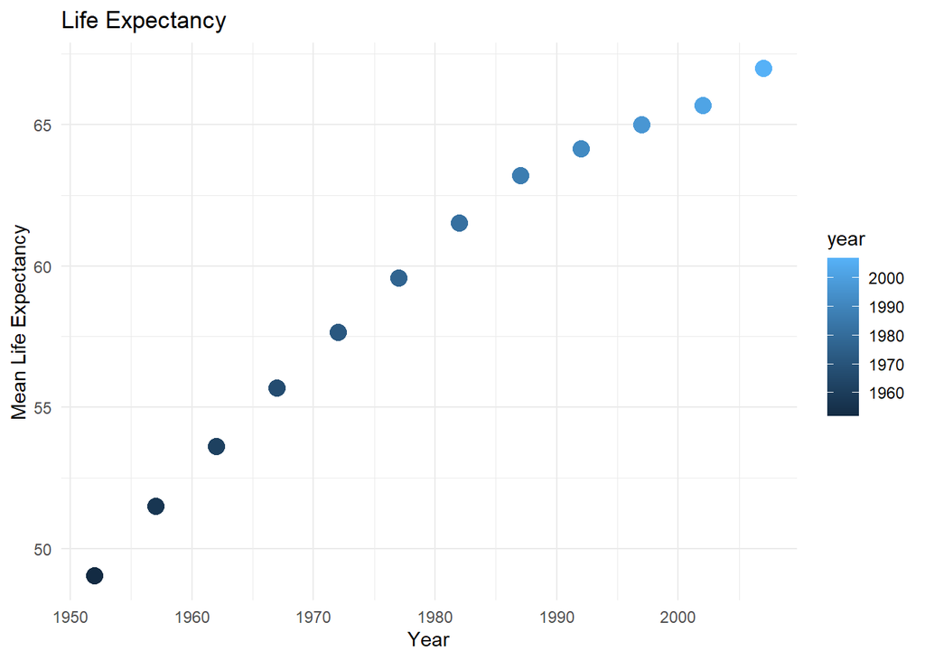

```r
#create a ggplot with year as x axis and mean life expectancy on the y axis
ggplot(LE_by_yr) +
  theme_minimal() +
  geom_point(aes(x= year, y= (LE_mean), color= year), size= 4) +
  labs(title= "Life Expectancy", y= "Mean Life Expectancy", x= "Year")
```

## Question 5

**Pull in a dataset of your choice from the datasets package that has a dataframe structure (not sure what’s available, try ?datasets). Then examine the structure of the data including: class types, header information, and dimensions.**

```r
#looking at what datasets are available

library(help = "datasets")

#look at tibble to see my dataset headers and its classes
head(CO2, 5)
```

```
##   Plant   Type  Treatment conc uptake
## 1   Qn1 Quebec nonchilled   95   16.0
## 2   Qn1 Quebec nonchilled  175   30.4
## 3   Qn1 Quebec nonchilled  250   34.8
## 4   Qn1 Quebec nonchilled  350   37.2
## 5   Qn1 Quebec nonchilled  500   35.3
```

```r
#double check classes
class(CO2$Plant)
```

```
## [1] "ordered" "factor"
```

```r
class(CO2$Type)
```

```
## [1] "factor"
```

```r
class(CO2$Treatment)
```

```
## [1] "factor"
```

```r
class(CO2$conc)
```

```
## [1] "numeric"
```

```r
class(CO2$uptake)
```

```
## [1] "numeric"
```

```r
#double check dim
dim(CO2)
```

```
## [1] 84  5
```

## Question 6

**Calculate general summary statistics for the dataset.**

```
##      Plant             Type         Treatment       conc          uptake
##  Qn1    : 7   Quebec     :42   nonchilled:42   Min.   :  95   Min.   : 7.70
##  Qn2    : 7   Mississippi:42   chilled   :42   1st Qu.: 175   1st Qu.:17.90
##  Qn3    : 7                                    Median : 350   Median :28.30
##  Qc1    : 7                                    Mean   : 435   Mean   :27.21
##  Qc3    : 7                                    3rd Qu.: 675   3rd Qu.:37.12
##  Qc2    : 7                                    Max.   :1000   Max.   :45.50
##  (Other):42
```

## Question 7

**Calculate summary statistics for groups/subsets of the dataset (these groupings could be based on time period, species, location, etc…).**

```r
#mean uptake for type and treatment
CO2%>%
     group_by(Type, Treatment) %>%
     summarize(mean_uptake = mean(uptake))
```

```
## # A tibble: 4 x 3
## # Groups:   Type [2]
##   Type        Treatment  mean_uptake
##   <fct>       <fct>            <dbl>
## 1 Quebec      nonchilled        35.3
## 2 Quebec      chilled           31.8
## 3 Mississippi nonchilled        26.0
## 4 Mississippi chilled           15.8
```

```r
#mean uptake for treatment and concentration
CO2%>%
     group_by(Treatment, conc) %>%
     summarize(mean_uptake = mean(uptake))
```

```
## # A tibble: 14 x 3
## # Groups:   Treatment [2]
##    Treatment   conc mean_uptake
##    <fct>      <dbl>       <dbl>
##  1 nonchilled    95        13.3
##  2 nonchilled   175        25.1
##  3 nonchilled   250        32.5
##  4 nonchilled   350        35.1
##  5 nonchilled   500        35.1
##  6 nonchilled   675        36.0
##  7 nonchilled  1000        37.4
##  8 chilled       95        11.2
##  9 chilled      175        19.4
## 10 chilled      250        25.3
## 11 chilled      350        26.2
## 12 chilled      500        26.6
## 13 chilled      675        27.9
## 14 chilled     1000        29.8
```

```r
#mean uptake for plant
CO2%>%
     group_by(Plant) %>%
     summarize(mean_uptake = mean(uptake))
```

```
## # A tibble: 12 x 2
##    Plant mean_uptake
##    <ord>       <dbl>
##  1 Qn1          33.2
##  2 Qn2          35.2
##  3 Qn3          37.6
##  4 Qc1          30.0
##  5 Qc3          32.6
##  6 Qc2          32.7
##  7 Mn3          24.1
##  8 Mn2          27.3
##  9 Mn1          26.4
## 10 Mc2          12.1
## 11 Mc3          17.3
## 12 Mc1          18
```

## Question 8

**Create 2 plots of your choice, one showing grouped data and the other showing ungrouped data. Give each plot a title and descriptive x and y axis labels. Customize at least one graphic option (color, point type, line width, etc…) on these plots.**

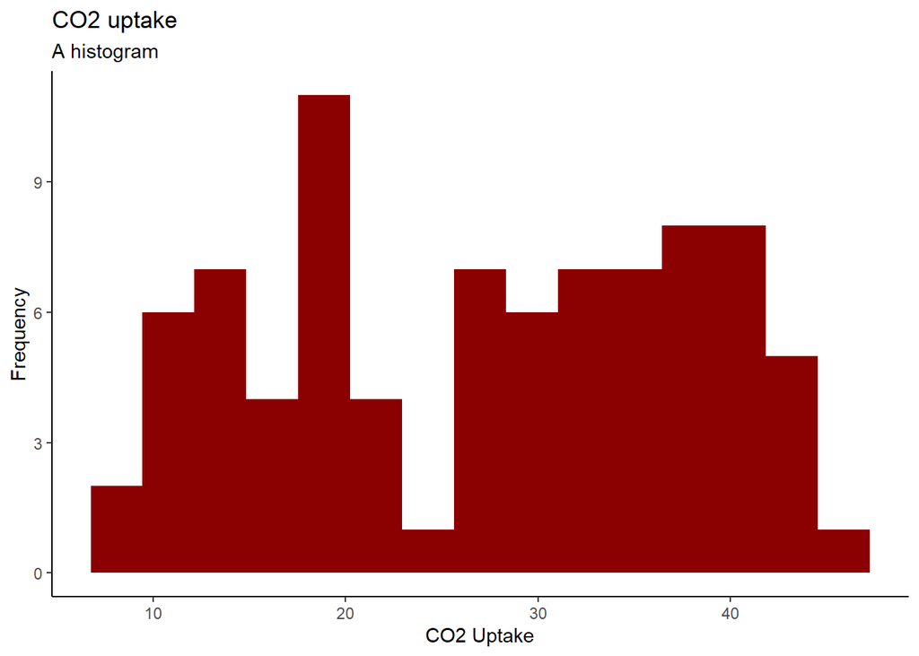

```r
#plot 1 ungrouped

ggplot(CO2) +
  geom_histogram(aes(x = uptake), fill = "darkred", bins = 15) +
  theme_classic()+
  labs(title = "CO2 uptake", subtitle = "A histogram") +
  xlab ("CO2 Uptake") +
  ylab ("Frequency")
```

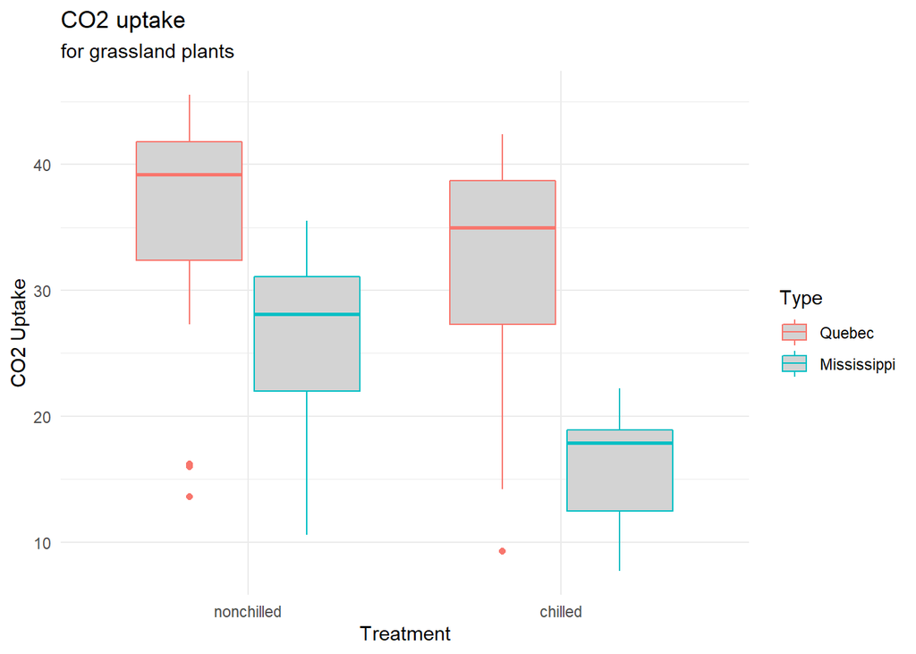

```r
#plot 2 grouped by treatment and type

ggplot(CO2) +
  geom_boxplot(aes(y = uptake , x= Treatment, color= Type), fill = "lightgray") +
  theme_minimal() +
  labs(title = "CO2 uptake", subtitle = "for grassland plants") +
  xlab ("Treatment") +
  ylab ("CO2 Uptake")
```